# Exponential regression

Παρακάτω δίνονται οι μετρήσεις ανά 30’ από έναν μετρητή Geiger από μια ατομική σχάση. Tα δεδομένα αποθηκεύονται υπό μορφή data frame (πίνακας) στην R.

```r
df<- data.frame(Time = c(0, 1, 2, 4, 6, 8, 9, 10, 11, 12, 13,
14, 15, 16, 18, 19, 20, 21, 22, 24, 25, 26, 27, 28, 29, 30),
Counts = c(126.6, 101.8, 71.6, 101.6, 68.1, 62.9, 45.5, 41.9,
46.3, 34.1, 38.2, 41.7, 24.7, 41.5, 36.6, 19.6,
22.8, 29.6, 23.5, 15.3, 13.4, 26.8, 9.8, 18.8, 25.9, 19.3))
```

Το αρχείο περιλαμβάνει 26 εγγραφές

```r
df
```

| Time | Counts |
| --- | --- |
| 0 | 126.6 |
| 1 | 101.8 |
| 2 | 71.6 |
| 4 | 101.6 |
| 6 | 68.1 |
| 8 | 62.9 |
| 9 | 45.5 |
| 10 | 41.9 |
| 11 | 46.3 |
| 12 | 34.1 |

[output cut: 16 more lines]

Οπτικοποιούμε την σχέση μεταξύ των δύο μεταβλητών. Είναι προφανές ότι η σχέση δεν είναι γραμμική αλλά εκθετική.

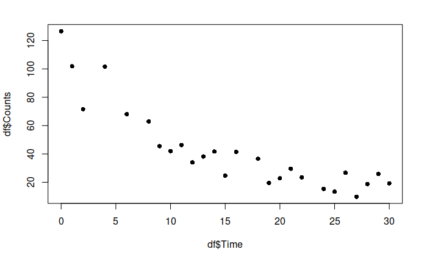

```r
plot(df$Time, df$Counts,pch=16)
```

Στην συνέχεια προσαρμόζουμε μια γραμμή ελαχίστων τετραγώνων εφαρμόζοντας ένα εκθετικό μοντέλο.

```r
exponential.model <- lm(log(Counts)~ Time, data=df)
```

Καλούμε την συνάρτηση summary για να δούμε λεπτομέρειες σχετικά με την απόδοση του μοντέλου.

```r
summary(exponential.model)
```

```
Call:
lm(formula = log(Counts) ~ Time, data = df)

Residuals:
     Min       1Q   Median       3Q      Max
-0.54715 -0.17618  0.02855  0.18850  0.55254

Coefficients:
             Estimate Std. Error t value Pr(>|t|)
(Intercept)  4.555249   0.111690   40.78  < 2e-16 ***
Time        -0.063915   0.006158  -10.38 2.36e-10 ***
---
Signif. codes:  0 ‘***’ 0.001 ‘**’ 0.01 ‘*’ 0.05 ‘.’ 0.1 ‘ ’ 1

Residual standard error: 0.2814 on 24 degrees of freedom
Multiple R-squared:  0.8178,    Adjusted R-squared:  0.8102
F-statistic: 107.7 on 1 and 24 DF,  p-value: 2.362e-10
```

Ο συντελεστής προσδιορισμού είναι αρκετά ισχυρός (0,82) δηλαδή το 82% της μεταβλητότητας των μετρήσεων εξαρτάται από την μεταβολή του χρόνου.

Στην συνέχεια θα προσαρμόσουμε μια γραμμή στο διάγραμμα διασποράς με βάση αυτό το μοντέλο. Για αυτό τον λόγο απαιτείται να γίνει πρόβλεψη τιμών για σημεία της γραμμής. Ορίζουμε για την ανεξάρτητη μεταβλητή (time) τιμές από 0 ως 30’ με βήμα 0.1’ και στην συνέχεια χρησιμοποιουμε το εκθετικό μοντέλο .

```r
timevalues <- seq(0, 30, 0.1)
Counts.exponential2 <- exp(predict(exponential.model,data.frame(Time=timevalues)))
head(Counts.exponential2, 20) # εκτύπωση των πρώτων 20 σημείων
```

```
       1        2        3        4        5        6        7        8        9       10       11       12       13       14
95.13047 94.52438 93.92215 93.32376 92.72918 92.13839 91.55136 90.96807 90.38850 89.81262 89.24041 88.67185 88.10691 87.54556
      15       16       17       18       19       20
86.98780 86.43358 85.88290 85.33573 84.79204 84.25182
```

Εκτυπώνουμε το διάγραμμα διασποράς μαζί με τα με την προσαρμοσμένη γραμμή:

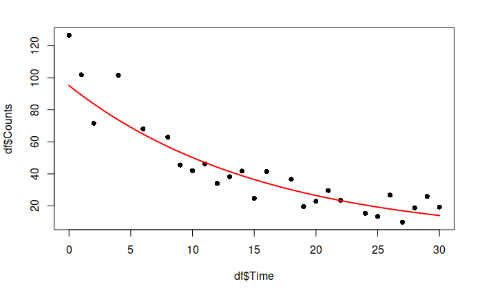

```r
plot(df$Time, df$Counts,pch=16)
lines(timevalues, Counts.exponential2,lwd=2, col = "red", xlab = "Time (s)", ylab = "Counts")
```

Μπορούμε να χρησιμοποιήσουμε το μοντέλο για να προβλέψουμε τιμές μετρήσεων σε συγκεκριμένο χρονικό διάστημα π.χ. 40 και 50’.

```r
# Predict
exp(predict(exponential.model,data.frame(Time=c(40,50))))
```

```
       1        2
7.378976 3.894173
```